# A Text Analysis of Trump’s Tweets

Bilsay Varcin

6/12/2020

## The tweets

I don’t usually post about politics (I’m not particularly savvy about polling, which is where data science has had the most substantial impact on politics), but I saw a hypothesis about Donald Trump’s Twitter account that simply begged to be investigated with data:

When Trump wished the Olympic team good luck, he was tweeting from an iPhone. When he insulted a rival, he was usually tweeting from an Android. Is this an artifact showing which tweets are Trump’s own and which are by some handler in the 2016 campaign?

Others have explored Trump’s timeline and noticed this tends to hold up. And Trump himself did indeed tweet from a Samsung Galaxy until March 2017. But how could we examine it quantitatively? During the development of the tidytext R package, I was writing about writing about text mining and sentiment analysis, and this is an excellent opportunity to apply it again.

Let’s load the content of Donald Trump’s timeline. Our dataset is from The Trump Twitter Archive by Brendan Brown, which contains all 35,000+ tweets from the @realDonaldTrump Twitter account from 2009 (the year Trump sent his first tweet) through 2018. We’ll filter it for the election period only, June 1, 2015 through November 8, 2016.

## Clean those tweets

We’ll clean the data by extracting the source application. We’re only looking at the iPhone and Android tweets. A much smaller number of tweets are from the web client or iPad.

Overall, the cleaned data should include 2275 tweets from an iPhone device and 4240 tweets from an Android device.

## Is “time” the giveaway?

Most people are creatures of habit, and we would expect their tweet times to be a type of ‘signature’. We can certainly spot the difference here. Most tweets from the Android are in the early morning or later in the evening, while tweets from the iPhone occur more often in the afternoon.

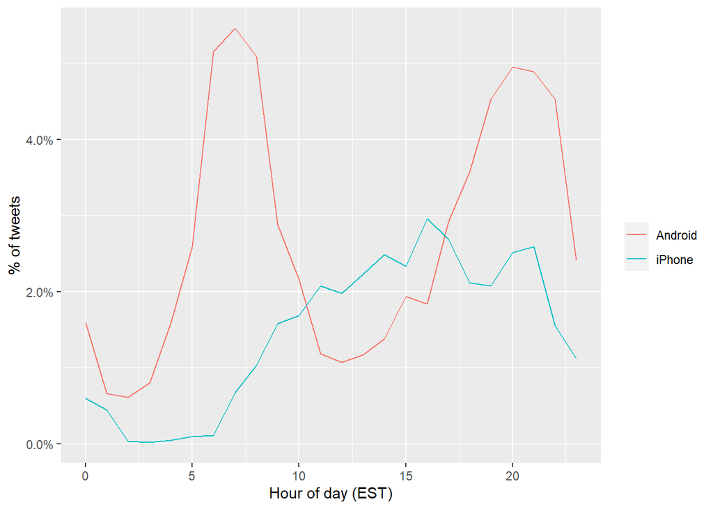

## The quote tweet is dead

Another place we can spot a difference is in Trump’s anachronistic behavior of “manually retweeting” people by copy-pasting their tweets, then surrounding them with quotation marks. These are known as quote tweets.

Almost all the quote tweets are posted from the Android.

After this plot, we’ll filter out the quote tweets in the remaining by-word analyses because they contain text from followers that may not be representative of Trump’s tweets.

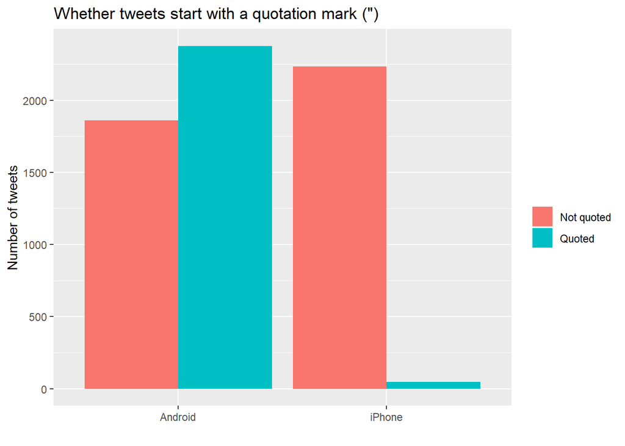

## Another place we see a difference between the iPhone and Android tweets is in the sharing of links or pictures.

It turns out that tweets from the iPhone were way more likely to contain either a picture or a link. This also makes sense with our narrative: iPhone (presumably run by the campaign) tends to write “announcement” tweets about events.

While Android (Trump himself) tends to write picture-less tweets.

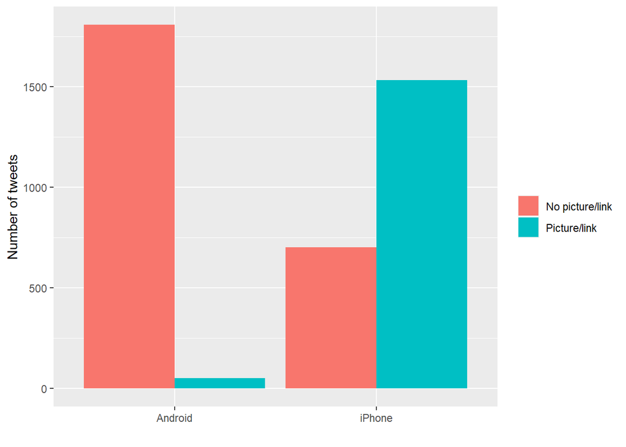

## Comparison of words

Now that we’re sure there is a difference between these two platforms, what can we say about the difference in the content of the tweets? We’ll use the tidytext package that Julia Silge and I developed.

We start by dividing lines of text into individual words using unnest_tokens() (see this vignette for more), and by removing some common “stopwords”.

```
## # A tibble: 6 x 4
##    id_str source  created_at          word
##     <dbl> <chr>   <dttm>              <chr>
## 1 6.05e17 Android 2015-06-01 10:23:13 @foxandfriends
## 2 6.05e17 Android 2015-06-01 10:23:13 enjoy
## 3 6.07e17 Android 2015-06-05 03:55:04 worst
## 4 6.07e17 Android 2015-06-05 03:55:04 boring
## 5 6.07e17 Android 2015-06-05 03:55:04 political
## 6 6.07e17 Android 2015-06-05 03:55:04 pundits
```

## Most common words

What are the most common words @realDonaldTrump tweets? This plot should look familiar to anyone who has seen the feed.

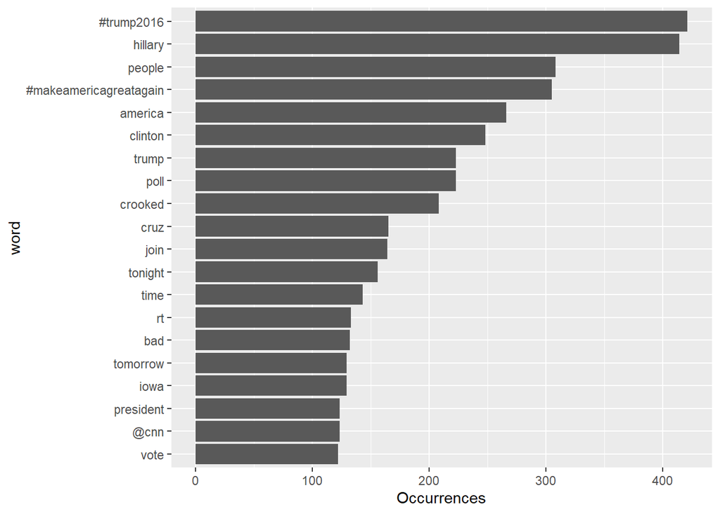

## Common words: Android vs. iPhone (i)

The “ +1+1 ”, called Laplace smoothing, are to avoid dividing by zero and to put more trust in common words.

```r
# Create the log odds ratio of each word
android_iphone_ratios <- tweet_words %>%
  count(word, source) %>%
  group_by(word)  %>%
  filter(sum(n) >= 5) %>%
  spread(source, n, fill = 0) %>%
  ungroup() %>%
  mutate_if(is.numeric, ~((. + 1) / sum(. + 1))) %>%
  mutate(logratio = log2(Android / iPhone)) %>%
  arrange(desc(logratio))

# Inspect the first six rows
head(android_iphone_ratios)
```

```
## # A tibble: 6 x 4
##   word       Android    iPhone logratio
##   <chr>        <dbl>     <dbl>    <dbl>
## 1 mails     0.00167  0.0000796     4.39
## 2 poor      0.00102  0.0000796     3.67
## 3 poorly    0.000944 0.0000796     3.57
## 4 bosses    0.000871 0.0000796     3.45
## 5 turnberry 0.000871 0.0000796     3.45
## 6 angry     0.000798 0.0000796     3.33
```

## Common words: Android vs. iPhone (ii)

Now that we’ve calculated the log odds ratio of each word, we’ll plot the 15 words with the greatest log odds ratio for the Android and the iPhone.

With the way we’ve set up the log odds ratio, positive values are assigned to words from the Android, and negative values are assigned to the iPhone.

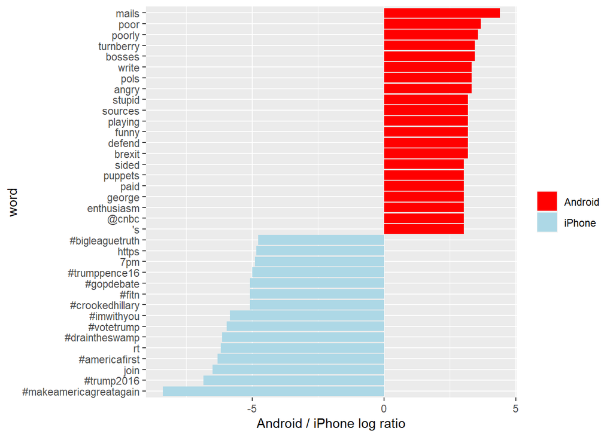

```r
# Plot the log odds ratio for each word by device
android_iphone_ratios %>%
  group_by(logratio > 0) %>%
  top_n(15, abs(logratio)) %>%
  ungroup() %>%
  mutate(word = reorder(word, logratio)) %>%
  ggplot(aes(word, logratio, fill = logratio < 0)) +
  geom_bar(stat = "identity") +
  coord_flip() +
  ylab("Android / iPhone log ratio") +
  scale_fill_manual(name = "", labels = c("Android", "iPhone"),
                    values = c("red", "lightblue"))
```

## Adding sentiments

What do we know so far?

- Most hashtags come from the iPhone. Indeed, almost no tweets from Trump’s Android contained hashtags, with some rare exceptions like this one. (This is true only because we filtered out the quoted “retweets,” as Trump does sometimes quote tweets like this that contain hashtags).
- Words like “join” and times like “7 pm”, came only from the iPhone. The iPhone is responsible for event announcements like this one (“Join me in Houston, Texas tomorrow night at 7 pm!”)
- Emotionally charged words, like “poorly,” “angry,” and “stupid” were more common on Android. This supports the original hypothesis that this is the “angrier” or more hyperbolic account.

Since we’ve observed a difference in word use between the Android and iPhone tweets, let’s see if there’s a difference in sentiment. We’ll work with the NRC Word-Emotion Association lexicon, available from the tidytext package, which associates words with ten sentiments: positive, negative, anger, anticipation, disgust, fear, joy, sadness, surprise, and trust.

```r
# Create a sentiment data frame from the NRC lexicon
nrc <- read_rds("data/nrc.rds")

# Join the NRC lexicon to log odds ratio data frame
android_iphone_sentiment <- android_iphone_ratios %>%
  inner_join(nrc, by = "word") %>%
  filter(!sentiment %in% c("positive", "negative")) %>%
  mutate(sentiment = reorder(sentiment, -logratio),
         word = reorder(word, -logratio)) %>%
  group_by(sentiment) %>%
  top_n(10, abs(logratio)) %>%
  ungroup()

# Inspect the first six rows
head(android_iphone_sentiment)
```

```
## # A tibble: 6 x 5
##   word        Android    iPhone logratio sentiment
##   <fct>         <dbl>     <dbl>    <dbl> <fct>
## 1 angry      0.000798 0.0000796     3.33 anger
## 2 angry      0.000798 0.0000796     3.33 disgust
## 3 defend     0.000726 0.0000796     3.19 fear
## 4 enthusiasm 0.000653 0.0000796     3.04 anticipation
## 5 enthusiasm 0.000653 0.0000796     3.04 joy
## 6 enthusiasm 0.000653 0.0000796     3.04 surprise
```

## Android vs. iPhone sentiments

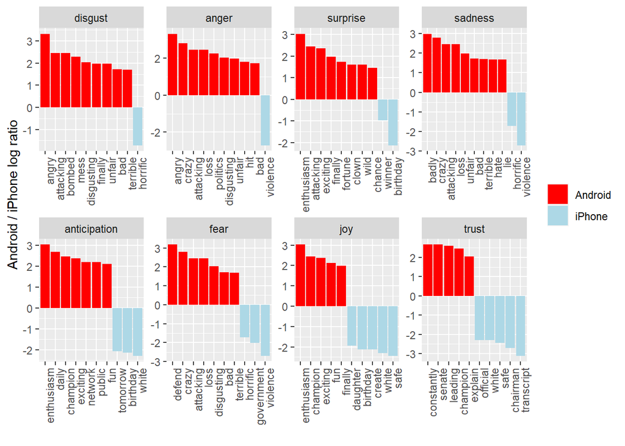

```r
# Plot the log odds ratio of words by device in groups sentiments
ggplot(android_iphone_sentiment, aes(word, logratio, fill = logratio < 0)) +
  facet_wrap(~ sentiment, scales = "free", nrow = 2) +
  geom_bar(stat = "identity") +
  theme(axis.text.x = element_text(angle = 90, hjust = 1)) +
  labs(x = "", y = "Android / iPhone log ratio") +
  scale_fill_manual(name = "", labels = c("Android", "iPhone"),
                    values = c("red", "lightblue"))
```

## Conclusion: The ghost in the political machine

There’s a difference in style and sentiment between Trump’s tweets from the Android and the iPhone. We know Trump used the Android until March 2017, but who was tweeting from the iPhone on Trump’s behalf? I was fascinated by a New Yorker article about Tony Schwartz, Trump’s ghostwriter for The Art of the Deal. Of particular interest was how Schwartz imitated Trump’s voice and philosophy:

In his journal, Schwartz describes the process of trying to make Trump’s voice palatable in the book. It was kind of “a trick,” he writes, to mimic Trump’s blunt, staccato, no-apologies delivery while making him seem almost boyishly appealing…. Looking back at the text now, Schwartz says, “I created a character far more winning than Trump is.”

A lot has been written about Trump’s mental state. But I’d rather get inside the head of the anonymous staffer whose job is to imitate Trump’s unique cadence (“Very sad!”) or put a positive spin on it, to millions of his followers. Are they a true believer, or just a cog in a political machine, mixing whatever mainstream appeal they can into the @realDonaldTrump concoction? Like Tony Schwartz, will they one day regret their involvement?